# systemsbio

Frank Ruehle

2019-07-15

# Streamlined Analysis and Integration of Systems Biology Data

This package consists of modularized wrapper functions for multiple genomics analysis packages. It is designed for multi-omics analysis of expression, methylation and/or genotyping data. All modules can also be used individually. This includes (although not all described in this vignette yet):

- Differential gene expression analysis
- Differential methylation analysis
- Genome-wide association analysis
- Functional enrichment analysis
- Identification of transcription factor binding sites
- Coexpression Networks
- Integration of expression and methylation data
- eQTL/mQTL analysis
- Integrated data regional plots

## Installation

Install it from github using the `devtools` package: `devtools::install_github("frankRuehle/systemsbio", build_vignettes=TRUE)`

```r
library("systemsbio")
library("knitr")
```

## Expression Data

### Import microarray expression data

There are two functions to load gene expression data into an ExpressionSet object. If you are analyzing Illumina microarrays, use `read_Illu_expr_array()` for importing the probe sample profile and the control probe profile exported from GenomeStudio.

```
gex <- read_Illu_expr_array(
            dataFile = "SampleProbeProfile.txt",
            qcFile = "ControlProbeProfile.txt",
            sampleSheet = "sample_sheet.csv",
            sampleColumn = "Sample_Name",
            exprchip= "HumanHT-12 v4",
            org= "human",
            covarfile = "covariates.txt",  # optional for additional phenotypes
            method_norm = "none",
            transform= "log2"
            )
```

For other array formats, use `readData2eset()` to load numeric expression values and phenotype data. As for `read_Illu_expr_array()`, the expression data can directly be log2-transformed.

```
gex <- readData2eset(exprsData, phenoData, featureData=NULL,
                          ProbeID = "PROBE_ID",
                          sampleColumn = "Sample_Name",
                          groupColumn  = "Sample_Group",
                          experimentData = MIAME(),
                          arrayAnnotation= "Humanv4",
                          transform = log2,
                          organism= "human"
                          )
```

```r
library(beadarray)
library(Biobase)
beadarray::exprs(gex)[1:5, 1:5]
```

```
#>              sample0319 sample0236 sample0168 sample0223 sample0022
#> ILMN_1762337   5.757226   4.564071   7.945479   4.798014   7.929665
#> ILMN_2055271   7.942353   6.985672   8.210554   5.958342   5.062069
#> ILMN_1736007   7.030014   5.959351   5.514951   7.949941   6.165501
#> ILMN_2383229   5.656847   8.046068   7.680127   4.865733   7.066831
#> ILMN_1806310   6.454255   8.055756   5.452801   8.155959   4.790996
```

```r
Biobase::pData(gex)[,1:5]
```

```
#>            Sample_Name Sample_Group Sentrix_ID Sentrix_Position      Age
#> sample0319  sample0319        case1 9985134122                B 50.52977
#> sample0236  sample0236        case1 9985134122                G 56.29021
#> sample0168  sample0168        case1 9985134122                J 58.27789
#> sample0223  sample0223        case2 9985134122                C 52.56947
#> sample0022  sample0022        case2 9985134122                I 57.47023
#> sample0172  sample0172        case2 9985134141                A 62.56537
#> sample0080  sample0080      control 9989522021                A 48.08761
#> sample0065  sample0065      control 9989522021                B 50.27515
#> sample0081  sample0081      control 9989522021                C 52.24093
```

```r
Biobase::fData(gex)[1:5, ]
```

```
#>                   ProbeID     PROBE_ID SYMBOL  Status
#> ILMN_1762337 ILMN_1762337 ILMN_1762337    7A5 regular
#> ILMN_2055271 ILMN_2055271 ILMN_2055271   A1BG regular
#> ILMN_1736007 ILMN_1736007 ILMN_1736007   A1BG regular
#> ILMN_2383229 ILMN_2383229 ILMN_2383229   A1CF regular
#> ILMN_1806310 ILMN_1806310 ILMN_1806310   A1CF regular
```

## Quality control

The function `QC_expressionset()` performs quality control of the expression data utilizing Illumina internal control probes (if available) as well as quality control functions of the `arrayqualitymetrics` and `WGCNA` packages. The result files are stored in the directory given in `projectfolder`. Failed samples should be removed from the dataset.

```
qcMetrics <- QC_expressionset(gex, projectfolder="example_analysis/GEX/QC",
                    projectname="example", phDendro=c("Sample_Group", "Sentrix_ID"),
                    groupColumn = "Sample_Group", cex.dendroLabels = 1)
```

If internal Illmumina quality control probes are present, boxplots are prepared for all categories of control probes (see below) and are stored in the project folder. A technical note about Illumina control probes is available [here](https://www.illumina.com/Documents/products/technotes/technote_gene_expression_data_quality_control.pdf).

All results from `arrayqualitymetrics` (distance plots, principal component analysis, array intensity distribution, density and MA plots) including outlier detection and further description are stored in the subfolder `quality_metrics`. Finally, a sample dendrogram including outlier detection is prepared using the `WGCNA` package.

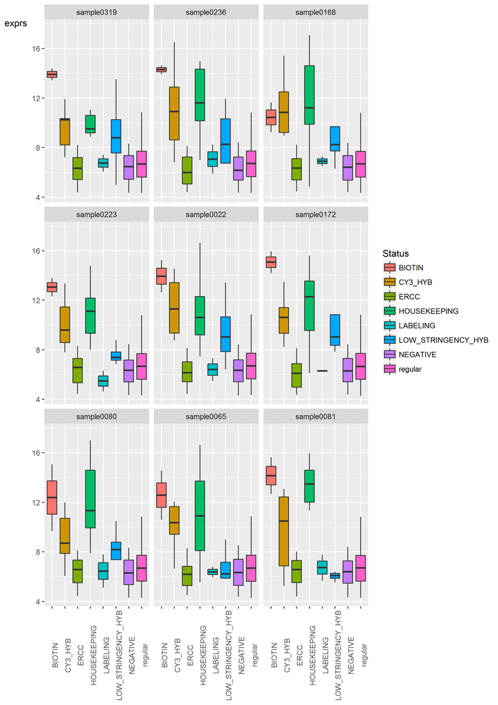

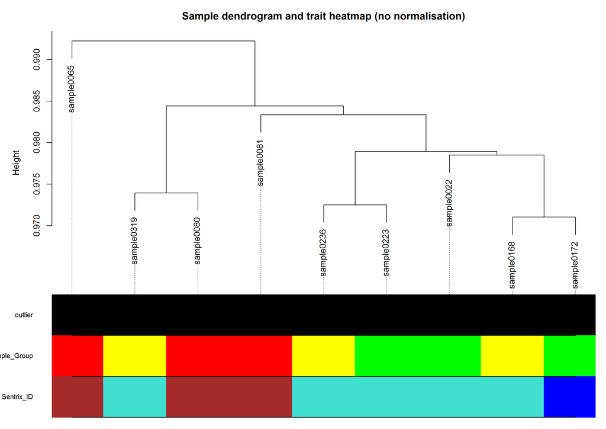

```r
deg_images<-c("figures/example_boxplot_controlprofile.png",
                         "figures/example_SampleDendrogram_noNorm_adjacency.png")
include_graphics(deg_images)
```

For quality control, look at different quality characteristics and make a decision which samples to remove. Usually, low quality samples look bad in several ways. Here, no sample had to be removed. If you have low quality samples in your dataset, remove them as indicated here:

```
gex <- gex[, !sampleNames(gex) %in% c("samplenamesToRemove")]
```

## Normalize expression set

Next, the dataset will be quantile-normalized using the `process_eset()` function. log2-transformation is not necessary, since the data has already been log2-transformed.

```
gexn <- process_eset(gex, method_norm="quantile", transform="none")
```

## Import RNA-Seq count data

Use `DESeq2::DESeqDataSetFromHTSeqCount` function to import count data e.g. from HTSEQ-count into a `DESeqDataSet` object. Here, “Sample_Group” given in the design formula is the phenotype used for differential expression analysis

```
dds <- DESeqDataSetFromHTSeqCount(sampleTable = data.frame(sampleName = your_sample_names,
                                                           fileName = your_file_names,
                                                           your_sample_phenotypes,
                                  directory = your_directory,
                                  design = ~ Sample_Group)
```

DESeq2 uses un-normalized count data for differential expression analysis. To obtain an expression matrix to be used for PCA, etc, you may process the count data e.g. by filtering low abundance transcripts and transform the data e.g. by applying Variance stabilizing transformation. The function `process_dds` processes the `DESeqDataSet` and returns a `SummarizedExperiment` object to be used for further analysis.

```
sumexp.vst <- process_dds(dds,
                          min_rowsum = 10,
                          transform.function = varianceStabilizingTransformation,
                          return_SummarizedExperiment = TRUE)
```

## Principal component analysis (PCA) and enrichment analysis of PC loadings

The `pcaGoPromoter` package provides functions for PCA analysis as well as for annotated PCA plots of the given expression data. Additionally, the top PC loadings (features most strongly correlated with PCs) are used for enrichment analysis with respect to gene ontology terms (GO) and transcription factor binding sites (TFBS). The wrapper function used here prepares the respective 2d and 3d PCA plots with respect to sample group assignment for the principal components indicated in the function call. The loadings of each PC are used for enrichment analysis and added to the annotated PCA plot. All plots and result tables are stored in the project folder.

```
pca.gexn <- wrapPCAgoprom(gexn, groupsoi=c('case1', 'case2', 'control'),
                           projectname="example", projectfolder = "example_analysis/GEX/pcaGoPromoter",
                           sample.name.column = "Sample_Name", inputType = "geneSymbol",
                           PCs4table = 3, PCs2plot = c(1,2,3), probes2enrich = 0.025)
```

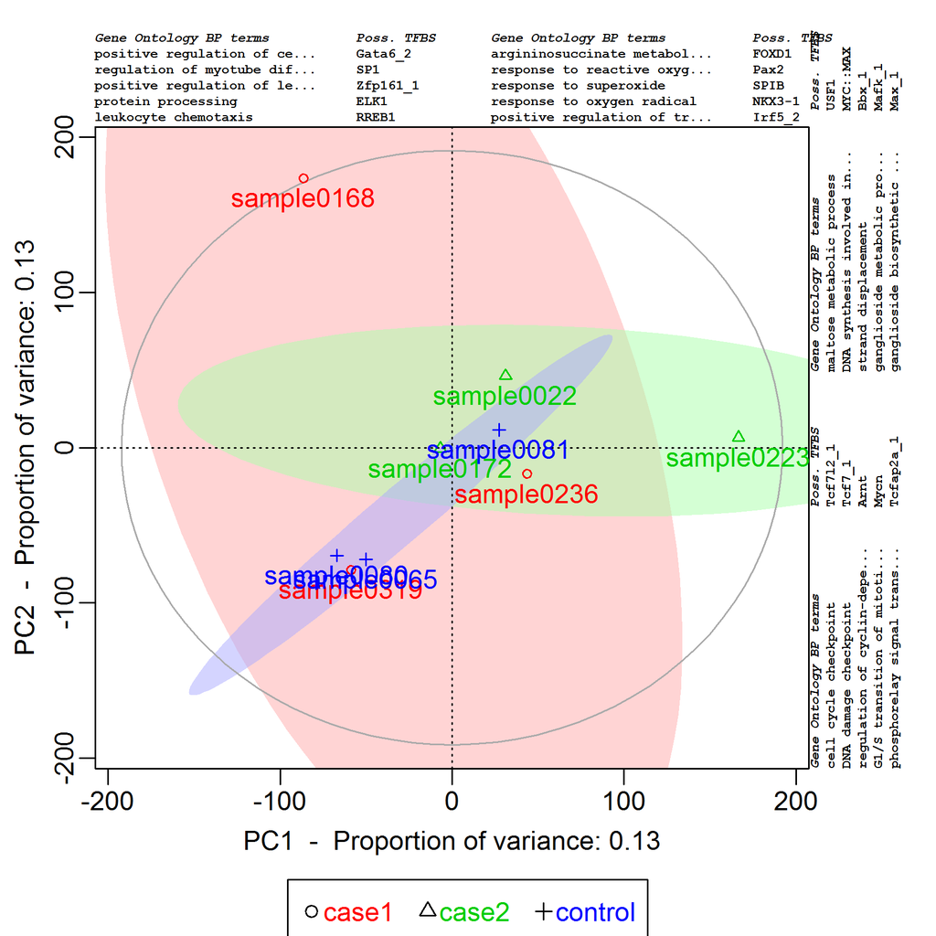

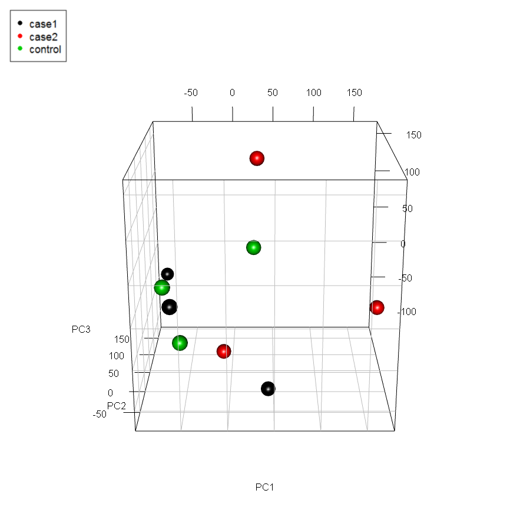

```r
deg_images<-c("figures/example_pcainfoplot_PC1_2.png",
              "figures/example_pcaplot3d_PC1_2_3.png")
include_graphics(deg_images)
```

## Weighted Gene Co-expression Network Analysis (WGCNA)

The `WGCNA` package is used for for preparing an unscaled co-expression network and for identifying modules of co-expressed genes. The wrapper function `wrapWGCNA()` used here performes all steps in the process automatically. First, you need to determine the adequate soft threshold power to prepare a scale free network. The function `wrapWGCNA()` can be run with parameter `softThresholdPower = NULL` to prepare an overview plot for selecting a soft threshold power with r2 > 0.85. Otherwise, you can let the function choose an appropriate threshold with `softThresholdPower= "auto"`or set the value directly.

```
wgcnaSFT.gexn <- wrapWGCNA(gexn, projectfolder= "example_analysis/GEX/WGCNA", softThresholdPower = NULL)
```

However, since we have a very small and artificial dataset in `gexn`, the resulting network does not have a scalefree topology. For this example, we choose a softThresholdPower of 12. In the next run of `wrapWGCNA()`, the network is constructed and co-expressed modules are identified. Additional parameters for finetuning the network (e.g. `detectCutHeight`, `deepSplit`, `minModuleSize`) can be transfered to `WGCNA::blockwiseModules` via the `...`-parameter. See `help(blockwiseModules)` for details. Genes not assigned to a module are collected in the default ‘grey’ module. A sample dendrogram, a gene dendrogramm(s) with phenotype information as well as boxplots of all modules are prepared and stored in the project folder.

```
wgcnaNET.gexn <- wrapWGCNA(gexn,
                  projectfolder= "example_analysis/GEX/WGCNA",
                  softThresholdPower= 12,
                  corType= "bicor",
                  networkType = "signed", # inversely correlated genes not in one module
                  TOMType = "signed",
                  maxBlockSize = 5000, # analysis devided into blocks
                  TOMplot= F, MDSplot= F,
                  phDendro= c("Sample_Group"),
                  phModule= c("Sample_Group", "Age"),
                  sampleColumn = "Sample_Name",
                  groupColumn  = "Sample_Group",
                  groupsets= c("case1-control", "case2-control"),
                  symbolColumn = "SYMBOL",
                  flashClustMethod = "average",
                  dendroRowText=T, autoColorHeight = FALSE,
                  colorHeight=0.2, cex.labels = 1,
                  detectCutHeight = 0.8,
                  deepSplit = 0,
                  minModuleSize = 75)
```

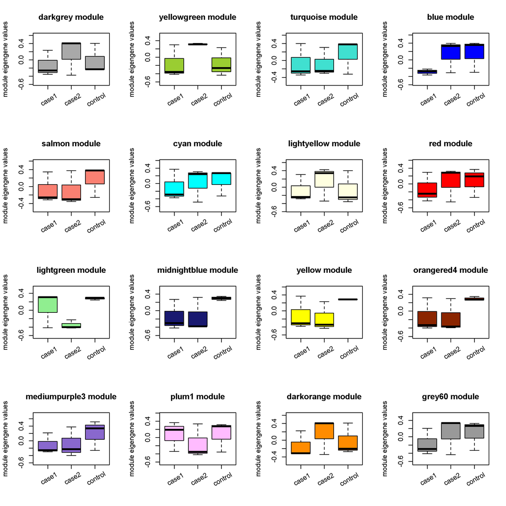

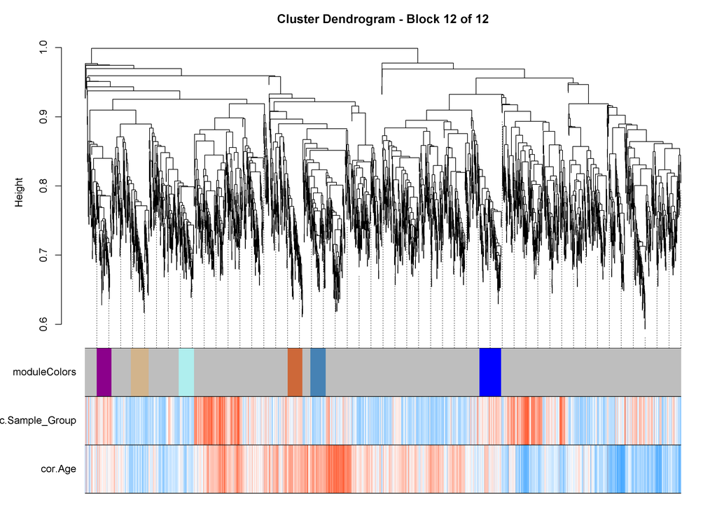

```r
deg_images<-c("figures/module_boxplot_1_of_3.png",
              "figures/ModuleDendrogram_Block.png")
include_graphics(deg_images)
```

The modules are correlated with phenotypes of interest given in `phModule` as well as with group assignments given in `groupsets`. The correlation results are illustrated in heatmaps. Next, correlated genes of high connectivity (hub genes) within their module are identified and are illustrated in scatter plots (correlation with phenotype/groupset vs. module membership). All result data is also stored as tables within the project folder.

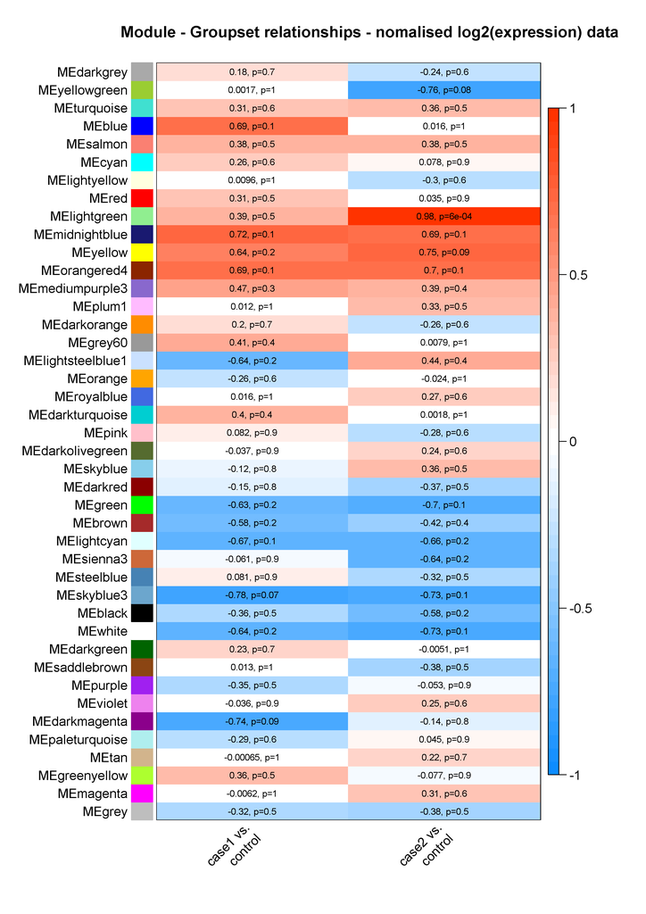

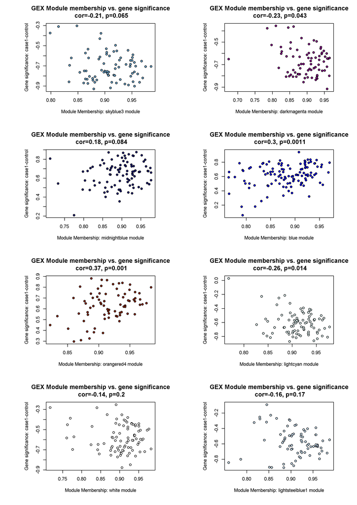

```r
deg_images<-c("figures/Heatmap_Module-Groupset_relationship.png",
              "figures/Intramodular_analysis_case1-control.png")
include_graphics(deg_images)
```

## Differential gene expression analysis with Limma

`wrapLimma` uses the `limma` package to determine differentially expressed genes according to the given p-value and fold change thresholds for all group comparisons given in `comparisons`. Tables containing the filtered as well as unfiltered gene lists are stored in the designated `projectfolder`. Heatmaps for each group comparison containg the top differentially expressed genes will be generated automatically. Venn-Diagrams will show the overlap of differentially expressed genes from different group comparisons.

```
deg <- wrapLimma(gexn,
                 comparisons = c("case1-control", "case2-control"),
                 p.value.threshold = 0.05,
                 FC.threshold = log2(1.5),
                 adjust.method = "BH",
                 projectfolder = "example_analysis/GEX/limma",
                 projectname = "example",
                 Symbol.column = "SYMBOL",
                 geneAnno2keep = c("SYMBOL", "ENTREZID"),
                 venn_comparisons = list(allcomp= c("case1-control", "case2-control")),
                 # Heatmap parameter:
                 maxHM = 50,
                 scale = c("none"),
                 HMincludeRelevantSamplesOnly = TRUE
                 )
```

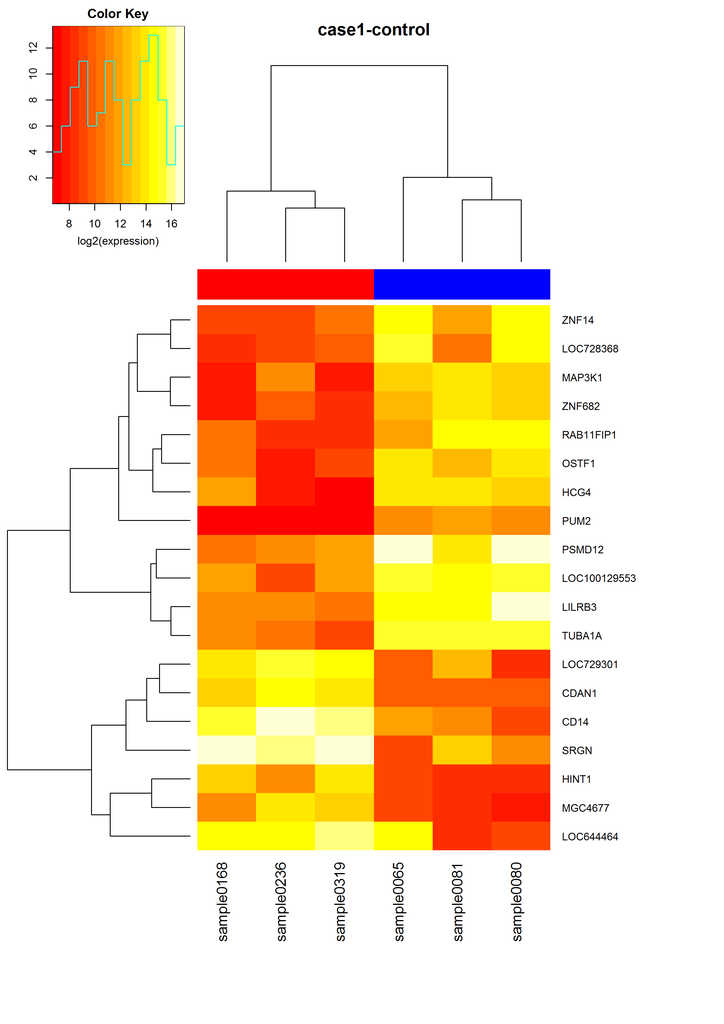

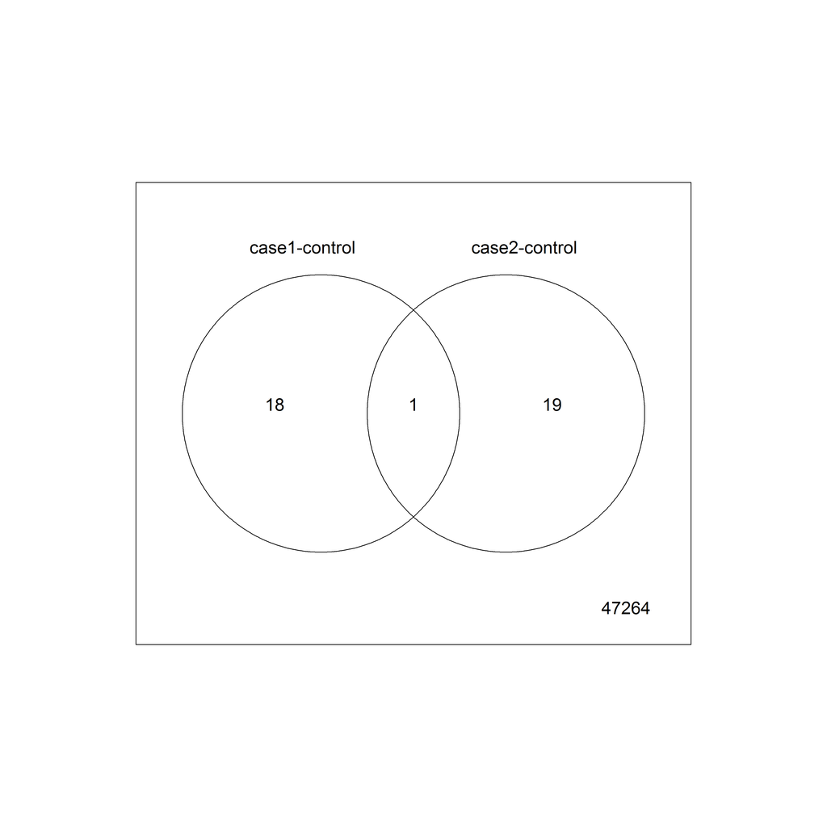

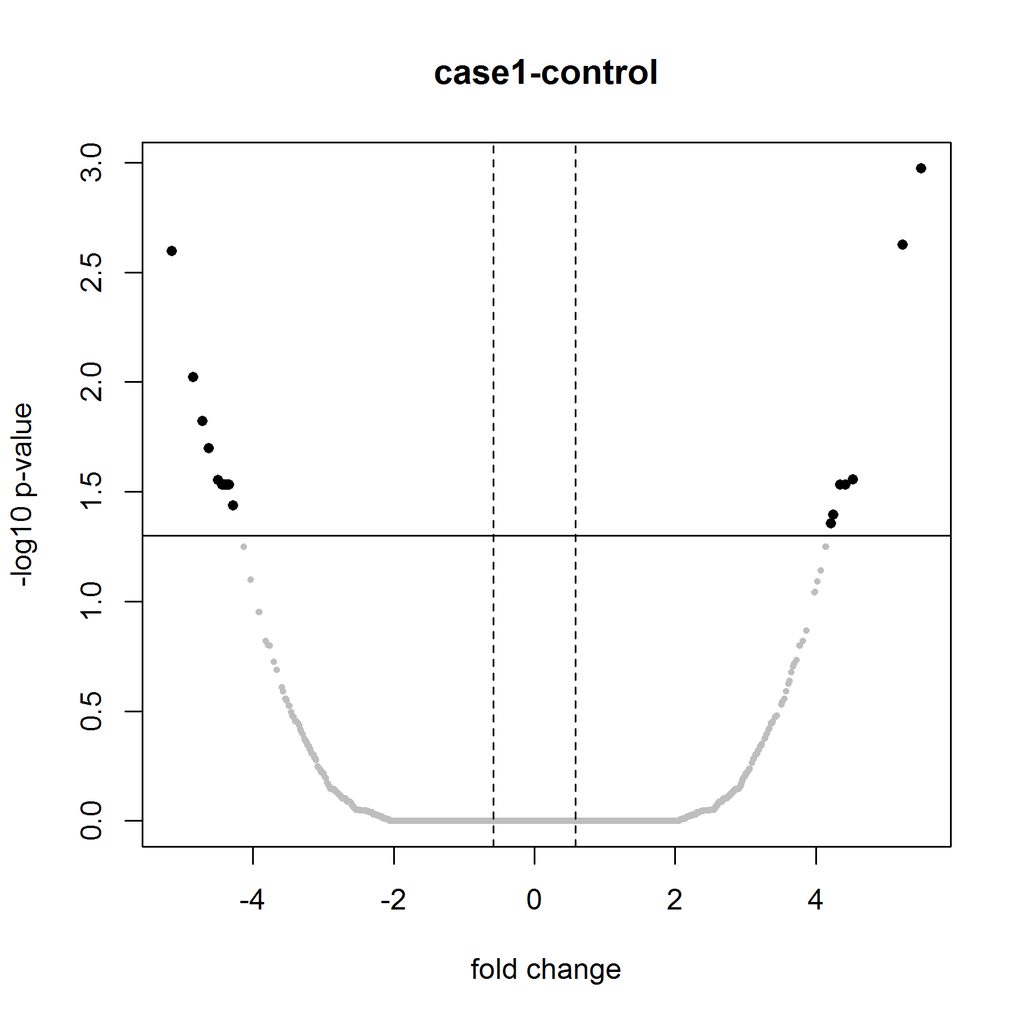

```r
deg_images<-c("figures/Heatmap_example_case1-control.png",
              "figures/Venn_Diagram_example_allcomp.png",
              "figures/Volcano_example_case1-control.png")
include_graphics(deg_images)
```

## Differential gene expression analysis with DESeq2

Similarily, count data from RNA-Seq can be analysed for differential expression using the `DESeq2` package. The wrapper function `wrapDESeq2` works analogously to `diffLimma` as described above.

```
deg <- wrapDESeq2(dds,
                  comparisons = c("case1-control", "case2-control"),
                  min_rowsum = 10,
                  p.value.threshold = 0.05,
                  adjust.method ="BH",
                  FC.threshold = log2(1.5),
                  projectfolder = "example_analysis/GEX/deseq",
                  projectname = "example",
                  Symbol.column = NULL,
                  sampleColumn = "Sample_Name",
                  groupColumn= "Sample_Group",
                  venn_comparisons= list(allcomp= c("case1-control", "case2-control")),
                  # Heatmap parameter:
                  maxHM=50,
                  scale = c("none"),
                  HMincludeRelevantSamplesOnly=TRUE
                  )
```

## Gene Enrichment analysis with clusterProfiler

The function `wrapClusterProfiler` takes genelist and optionally background gene list as input to perform enrichment analyses using the `clusterProfiler` package. By default, overrepresentation analysis and gene set enrichment analysis (GSEA) is performed for all categories given in `enrichmentCat`. While overrepresentation analysis applies a significance threshold to test the top genes, GSEA uses all genes of the list e.g. ranked by p-value. All result tables and plots (cnet plots, enrichment maps, dot plots, GOgraphs and KEGG pathway maps) are stored in the project folder.

```
clusterp.deg <- wrapClusterProfiler(deg[["DEgenes.unfilt"]],
                      backgroundlist = NULL,
                      projectfolder = "example_analysis/GEX/clusterProfiler",
                      projectname = "example",
                      enrichmentCat = c("GO", "KEGG", "Reactome", "DO"),
                      maxInputGenes = 100,
                      id.type = "SYMBOL",
                      id.column = "SYMBOL",
                      sortcolumn = "adj.P.Val",
                      highValueHighPriority = FALSE,
                      sortcolumn.threshold = 0.05,
                      fun.transform = function(x) {-log10(x)},
                      FCcolumn = "logFC",
                      threshold_FC = log2(1.5),
                      org = "human",
                      pAdjustMethod = "BH",
                      enrich.p.valueCutoff = 0.05,
                      enrich.q.valueCutoff = 0.05)

# access results e.g. for GO term (Biological Process) overrepresentation analysis of the
# first entry of deg[["DEgenes.unfilt"]], i.e. comparison case1-control
head(as.data.frame(clusterp.gexn[["case1-control"]]["Overrep_BP"]))
```

```r
Overrep_BP <- read.table("figures/example_case1-control_Overrep_BP_resulttable.txt", sep="\t", header=T)
head(Overrep_BP)
```

```
#>           ID                                           Description
#> 1 GO:0002758 innate immune response-activating signal transduction
#> 2 GO:0002218                  activation of innate immune response
#> 3 GO:0045089         positive regulation of innate immune response
#> 4 GO:0045088                  regulation of innate immune response
#> 5 GO:0031349               positive regulation of defense response
#> 6 GO:0002221        pattern recognition receptor signaling pathway
#>   GeneRatio   BgRatio       pvalue    p.adjust      qvalue
#> 1      4/13 261/15176 5.409592e-05 0.009663703 0.007279274
#> 2      4/13 267/15176 5.910522e-05 0.009663703 0.007279274
#> 3      4/13 309/15176 1.042337e-04 0.011361475 0.008558136
#> 4      4/13 373/15176 2.153368e-04 0.012738174 0.009595148
#> 5      4/13 401/15176 2.841203e-04 0.012738174 0.009595148
#> 6      3/13 159/15176 2.988040e-04 0.012738174 0.009595148
#>                    geneID Count
#> 1 CD14/PSMD12/PUM2/MAP3K1     4
#> 2 CD14/PSMD12/PUM2/MAP3K1     4
#> 3 CD14/PSMD12/PUM2/MAP3K1     4
#> 4 CD14/PSMD12/PUM2/MAP3K1     4
#> 5 CD14/PSMD12/PUM2/MAP3K1     4
#> 6        CD14/PUM2/MAP3K1     3
```

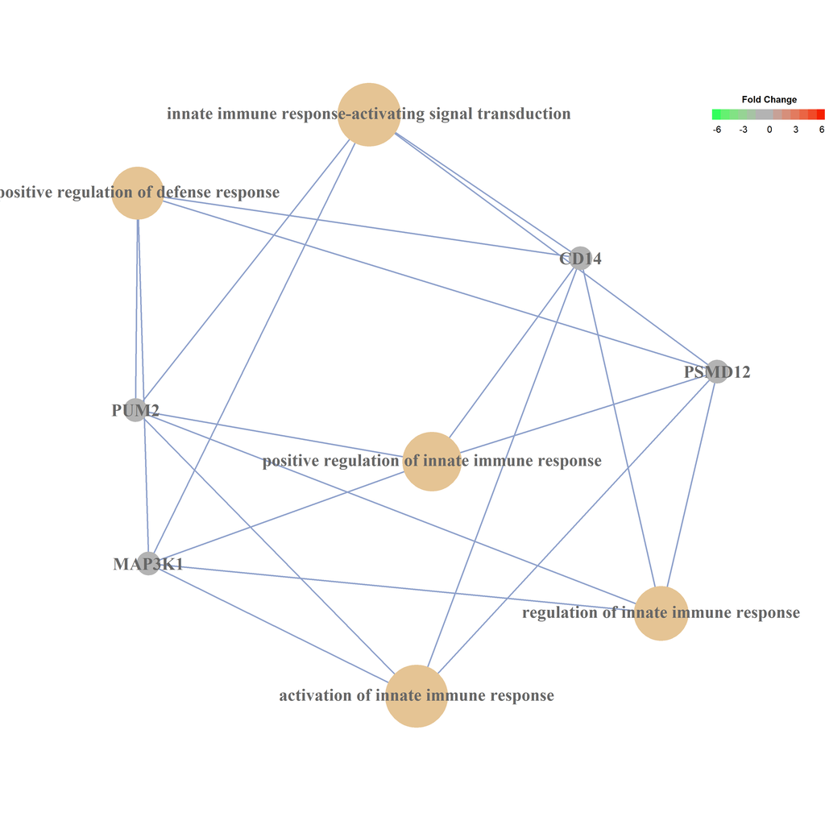

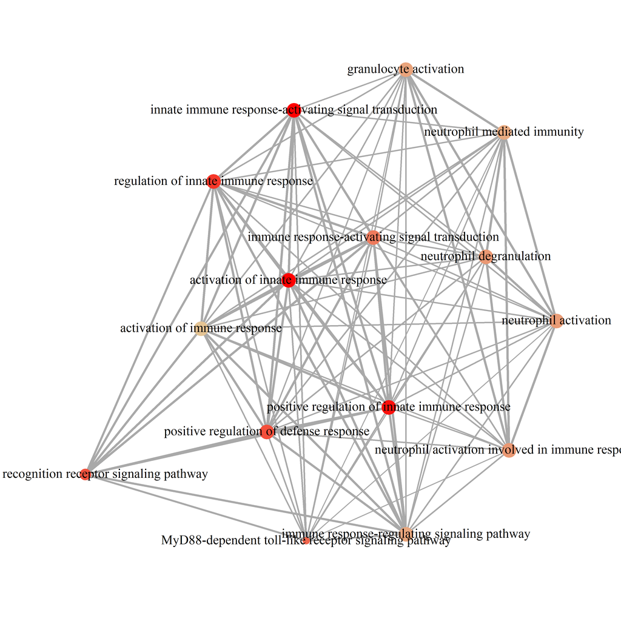

```r
deg_images<-c("figures/example_case1-control_Overrep_BP_cnetPlot.png",
              "figures/example_case1-control_Overrep_BP_enrichmentMap.png")
include_graphics(deg_images)
```

## Enrichment of Transcription Factor Binding sites (TFBS)

The function `wrapPWMEnrich` uses the `PWMEnrich` package to search for enriched TFBS within an input gene list. It looks up all promotor sequences for theses genes defined by indicated distance from trancription start site (TSS) refering to human genome build hg19. If gene symbols are given instead of entrez IDs, symbols are converted to entrez IDs first. If `PromLookup == FALSE`, look up of promotor sequences is omitted and sequences of interest must be given as gene coordinates (hg19) in `sequences` instead.  
Optionally, preselected motivs given in `SearchSelMotifs` are looked up in `sequences`. All result tables and plots are stored in the project folder.

```
tf.deg <- wrapPWMEnrich(deg[["DEgenes"]],
                     annoColumn = NULL,
                     name.organism = "hsapiens",
                     projectfolder= "example_analysis/GEX/TFBS",
                     projectname="example",
                     applyFilter = FALSE,
                     PromLookup = TRUE,
                     id.type = "SYMBOL",
                     id.column = "SYMBOL",
                     PromSeqUpstreamTSS = 2000,
                     PromSeqDownstreamTSS = 200,
                     SearchSelMotifs = NULL,
                     motif.min.score = 0.9)
```

```r
tf <- read.table("figures/example_case1-control_PWMEnrich_report.txt", sep="\t", header=T)
head(tf)
```

```
#>   rank        target                         id raw.score      p.value
#> 1    1         TFCP2 Hsapiens-jolma2013-TFCP2-2  1.692972 7.396826e-15
#> 2    2           MAX                 M4465_1.02  1.231083 4.157922e-12
#> 3    3 UW.Motif.0319              UW.Motif.0319  5.374850 3.439731e-11
#> 4    4 UW.Motif.0443              UW.Motif.0443  6.642932 6.965142e-11
#> 5    5 UW.Motif.0182              UW.Motif.0182  7.563387 1.525521e-10
#> 6    6        ZBTB7A  Hsapiens-jolma2013-ZBTB7A  3.126733 6.701743e-10
#>   top.motif.prop
#> 1      0.3518519
#> 2      0.2777778
#> 3      0.3148148
#> 4      0.3518519
#> 5      0.4629630
#> 6      0.3518519
```

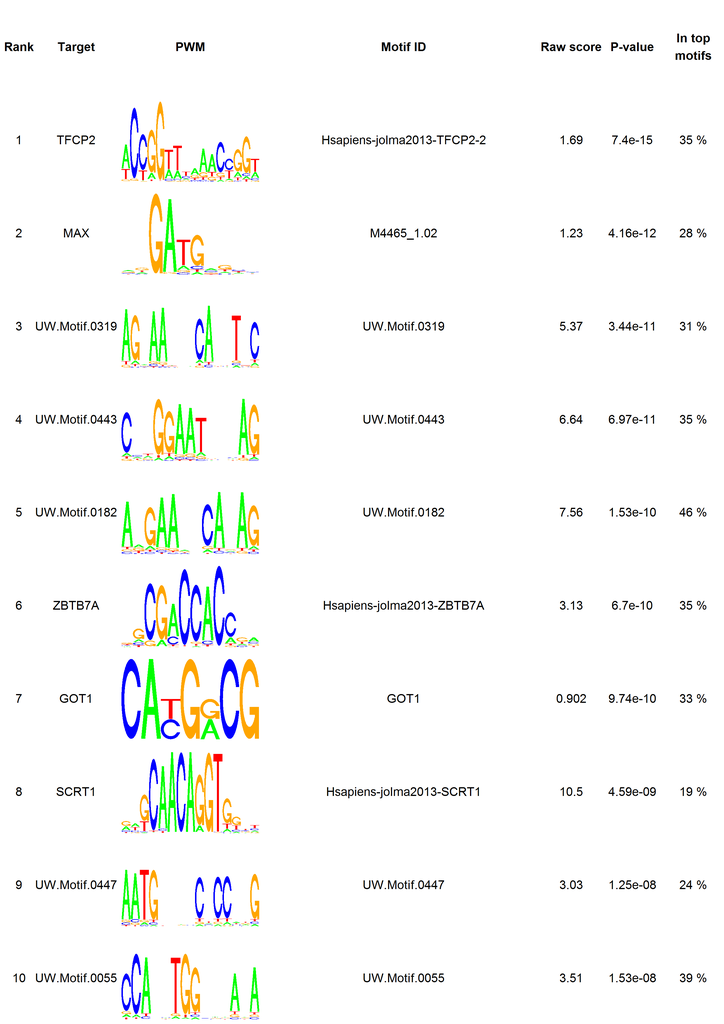

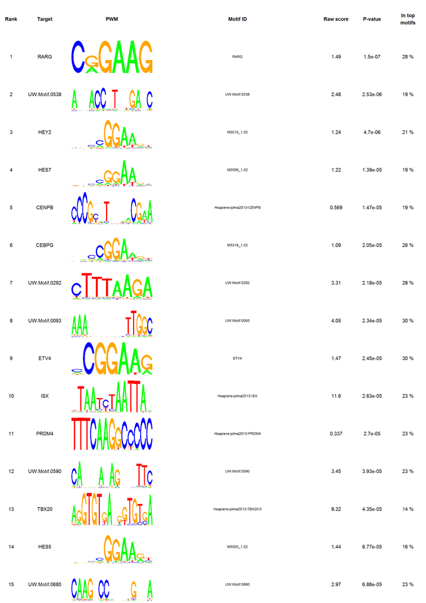

```r
deg_images<-c("figures/example_case1-control_PWMEnrich_top.png",
              "figures/example_case2-control_PWMEnrich_top.png")
include_graphics(deg_images)
```